# Spark_USPS_EDA

## 1. Payment Verification & Potential Fraud Indicators

```python
# Check frequency of payment indicators
df.groupBy("icr").count().show()

df.groupBy("manifest").count().show()
df.groupBy("icr_or_manifest").count().show()
```

```
+---+--------+
|icr|   count|
+---+--------+
|  1|14485394|
|  0|46770747|
+---+--------+

+--------+--------+
|manifest|   count|
+--------+--------+
|       1|59530688|
|       0| 1725453|
+--------+--------+

+---------------+--------+
|icr_or_manifest|   count|
+---------------+--------+
|              1|59572061|
|              0| 1684080|
+---------------+--------+
```

```python
paid_labels_both = df.filter((col("manifest") == 1) & (col("icr") == 1))
paid_labels_both.count()
```

```
14444021
```

```python
print(f'% icr or manifest: {59572061/total_rows*100}')
print(f'% both : {14444021/total_rows*100}')
print(f'% manifest: {59530688/(total_rows)*100}')
print(f'% only icr: {(14485394-14444021)/(total_rows)*100}')
```

```
% icr or manifest: 97.25075727509508
% both : 23.579710971345712
% manifest: 97.18321629173474
% only icr: 0.06754098336034586
```

```python
# Filter for unmanifested and unpaid labels
paid_labels = df.filter((col("manifest") == 1) | (col("icr") == 1))
unpaid_labels = df.filter((col("manifest") == 0) & (col("icr") == 0))
```

```python
# Analyze unpaid labels
unpaid_labels.groupBy("mailerid").count().orderBy(desc("count")).show()  # Top mailers with unpaid labels

unpaid_labels.groupBy("ServiceTypeCode").count().orderBy(desc("count")).show()  # Service types of unpaid labels
```

```
+--------------------+------+
|            mailerid| count|
+--------------------+------+
|6979be97c8584b9e3...|237381|
|76702231548327c2a...| 72451|
|a01660e6e325afa34...| 59495|
|e9296f916123ddbb4...| 51974|
|cc5d050474d494256...| 47353|
|65a33714b964bd1fa...| 33279|
|585c1e68a843308ed...| 32534|
|e18c57aa2d21d4f76...| 28964|
|6a921ce357cb9e5a2...| 23705|
|d50825e3bb457fb82...| 22832|
|ced0b7ef682a2827d...| 20897|
|f002c47fa90b93145...| 18415|
|4e4fc0a559233f6f6...| 16711|
|7906b639a996ffdbe...| 16657|
|be065cc06e879e803...| 13893|
|7607999c8053d37be...| 13742|
|df25de876037adff7...| 13537|
|b874b6ecb2c9cc6b0...| 13048|
|c187d7e575e1c438d...| 12551|
|cc9ebee87b07e6f9c...| 12220|
+--------------------+------+
only showing top 20 rows

+---------------+------+
|ServiceTypeCode| count|
+---------------+------+
|            001|307849|
|            055|292804|
|            144|230769|
|            359|216693|
|            346|162117|
|             55|133381|
|              1|129918|
|            020| 78264|
|            124| 51359|
|             20| 37277|
|            187| 14872|
|            019|  8742|
|             19|  3488|
|            888|  2226|
|            108|  2217|
|            219|  1716|
|            022|  1106|
|            362|   805|
|            058|   723|
|             22|   685|
+---------------+------+
only showing top 20 rows
```

```python
unpaid_labels.groupBy("CRID").count().orderBy(desc("count")).show()
```

```
+--------------------+------+
|                CRID| count|
+--------------------+------+
|428267fbe6933acb4...|362608|
|                NULL|340533|
|7041bb8fb6e26fbbb...| 65331|
|8b3684bf0c0407f40...| 61807|
|3fc3297d399a555cd...| 59723|
|5eae5a5498be90d17...| 50101|
|8c52b43f7b059afca...| 47353|
|b7d7c0eb5354d0a43...| 31026|
|affd1cd208e7f6f1d...| 30388|
|e8041f0c6dd20689e...| 29658|
|8b5293e6fd9ffc203...| 26209|
|67205c31c5065f9ea...| 22832|
|b1d885e4d99335253...| 21484|
|20636515c48a4b11d...| 18415|
|2b0dd7fd17acc2006...| 16550|
|60483d21deaf001cf...| 14516|
|cd4688ee3af18abfd...| 13794|
|804a01d0eadb83a52...| 13120|
|62334a82566bc1294...| 13048|
|ce877a7770a6858d5...| 12006|
+--------------------+------+
only showing top 20 rows
```

```python
paid_counts = paid_labels.groupby('mailerid').count().orderBy(desc("count")).withColumnRenamed('count', 'paid_count')
unpaid_counts = unpaid_labels.groupby('mailerid').count().orderBy(desc("count")).withColumnRenamed('count', 'unpaid_count')
merged_df = paid_counts.join(unpaid_counts, on='mailerid', how='outer')
merged_df = merged_df.fillna(0)
merged_df = merged_df.withColumn('percent_unpaid', col('unpaid_count') / (col('paid_count') + col('unpaid_count')) * 100)
```

```python
merged_df.orderBy(desc("unpaid_count")).show()
```

```
+--------------------+----------+------------+------------------+
|            mailerid|paid_count|unpaid_count|    percent_unpaid|
+--------------------+----------+------------+------------------+
|6979be97c8584b9e3...|      8989|      237381| 96.35142265697934|
|76702231548327c2a...|     19288|       72451| 78.97513598360565|
|a01660e6e325afa34...|    975478|       59495| 5.748459138547576|
|e9296f916123ddbb4...|    222524|       51974|18.934199884880766|
|cc5d050474d494256...|         0|       47353|             100.0|
|65a33714b964bd1fa...|       609|       33279| 98.20290368271955|
|585c1e68a843308ed...|         0|       32534|             100.0|
|e18c57aa2d21d4f76...|         1|       28964| 99.99654755739685|
|6a921ce357cb9e5a2...|         0|       23705|             100.0|
|d50825e3bb457fb82...|         0|       22832|             100.0|
|ced0b7ef682a2827d...|     33840|       20897| 38.17710141220746|
|f002c47fa90b93145...|         0|       18415|             100.0|
|4e4fc0a559233f6f6...|         0|       16711|             100.0|
|7906b639a996ffdbe...|      8674|       16657| 65.75737238956219|
|be065cc06e879e803...|     10174|       13893|57.726347280508584|
|7607999c8053d37be...|      9729|       13742|  58.5488475139534|
|df25de876037adff7...|         0|       13537|             100.0|
|b874b6ecb2c9cc6b0...|         0|       13048|             100.0|
|c187d7e575e1c438d...|         0|       12551|             100.0|
|cc9ebee87b07e6f9c...|         0|       12220|             100.0|
+--------------------+----------+------------+------------------+
only showing top 20 rows
```

```python
df.filter(df['mailerid'].startswith('6979be97c8584b9e3')).limit(20).show()
```

[output not shown]

[output cut: 8 more lines]

```python
# Analyze time to manifest
manifested_labels = df.filter(col("manifest") == 1)
manifested_labels.withColumn("time_to_manifest", col("manifest_createdtimestamp").cast(LongType()) - col("createdtimestamp").cast(LongType())).describe("time_to_manifest").show()
# convert to hours
manifested_labels.withColumn("time_to_manifest_hours", (col("manifest_createdtimestamp").cast(LongType()) - col("createdtimestamp").cast(LongType())) / 3600).describe("time_to_manifest_hours").show()
```

```
+-------+------------------+
|summary|  time_to_manifest|
+-------+------------------+
|  count|          58985812|
|   mean|  80907.5781637625|
| stddev|109983.65329362926|
|    min|              -557|
|    max|           1596731|
+-------+------------------+

+-------+----------------------+
|summary|time_to_manifest_hours|
+-------+----------------------+
|  count|              58985812|
|   mean|     22.47432726771182|
| stddev|    30.551014803785908|
|    min|  -0.15472222222222223|
|    max|     443.5363888888889|
+-------+----------------------+
```

## 2. Address Verification & Potential Fraud Indicators:

```python
# Find mismatches between destination addresses
mismatched_addresses = df.filter(col("ptsaddressid") != col("ptsphysicaladdressid"))
print(mismatched_addresses.count())  # Number of mismatches
print(f'% Mismatch Destination: {4646026/total_rows}')
# Analyze zip code differences
df.groupBy("firstzip_startzip_diff").count().orderBy(desc("count")).withColumn('perc', col('count')/total_rows).show()  # Frequency of differences
```

```
4646026
+----------------------+--------+-------------------+
|firstzip_startzip_diff|   count|               perc|
+----------------------+--------+-------------------+
|                 false|40991475| 0.6691814784741337|
|                  true|20264666|0.33081852152586627|
+----------------------+--------+-------------------+
```

```python
print(f'% Mismatch Destination: {4646026/total_rows}')
```

```
% Mismatch Destination: 0.07584588131335274
```

```python
mismatched_states = mismatched_addresses.select("destaddress_STATENAME", "physaddress_STATENAME")
pivot_table = mismatched_states.crosstab("destaddress_STATENAME", "physaddress_STATENAME").fillna(0)
pivot_table.show()
```

[output not shown]

[output cut: 9 more lines]

- SSF (Shipping Services File): This is an electronic file submitted by bulk mailers to the USPS, containing detailed information about each package in a shipment, including the intended origin ZIP code.
- SPEF (Shipment Partner Event File): This is a similar electronic file used by shipping partners (e.g., consolidators, freight forwarders) to provide the USPS with tracking information, including the expected origin ZIP code.

```python
df.groupBy("spef").count().withColumn('perc', col('count')/total_rows).show()
```

```
+----+--------+-------------------+
|spef|   count|               perc|
+----+--------+-------------------+
|   1|48871639| 0.7978243193608948|
|   0|12384502|0.20217568063910524|
+----+--------+-------------------+
```

### Destination State

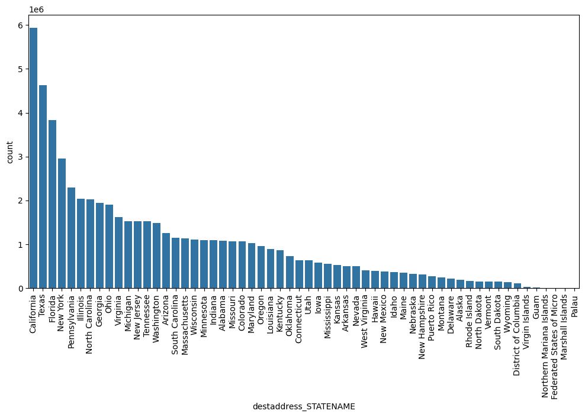

```python
# Visualize address distributions
import seaborn as sns
pandas_df = df.groupBy("destaddress_STATENAME").count().toPandas().sort_values(by='count', ascending=False)  #  states
plt.figure(figsize=(12, 6))
sns.barplot(x='destaddress_STATENAME', y='count', data=pandas_df)

plt.xticks(rotation=90)
plt.show()
```

### First scan state

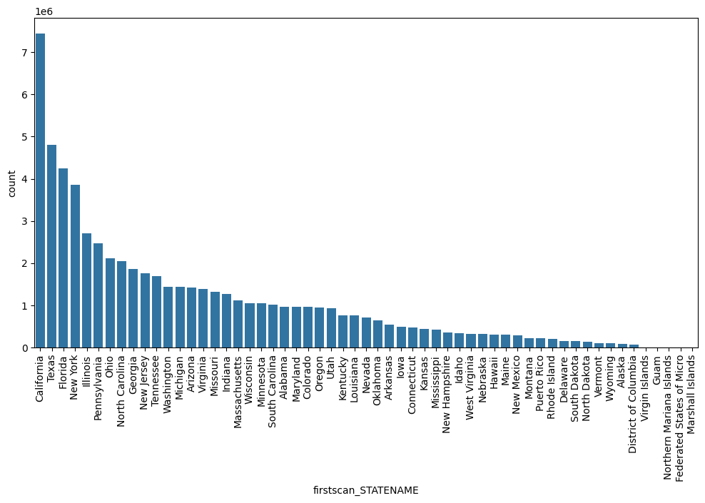

```python
pandas_df = df.groupBy("firstscan_STATENAME").count().toPandas().sort_values(by='count', ascending=False)  #  states
plt.figure(figsize=(12, 6))
sns.barplot(x='firstscan_STATENAME', y='count', data=pandas_df)

plt.xticks(rotation=90)
plt.show()
```

### startacceptance_STATECODE since STATENAME not in data

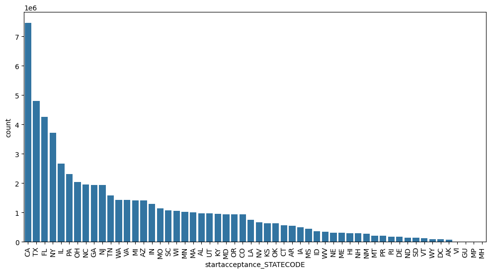

```python
pandas_df = df.groupBy("startacceptance_STATECODE").count().toPandas().sort_values(by='count', ascending=False)  #  states
plt.figure(figsize=(12, 6))
sns.barplot(x='startacceptance_STATECODE', y='count', data=pandas_df)

plt.xticks(rotation=90)
plt.show()
```

## 3. Mailer & Shipper Behavior

```python
## 3. Mailer & Shipper Behavior
# Analyze mailer activity
df.groupBy("mailerid").count().orderBy(desc("count")).withColumn('perc', col('count')/total_rows).show()  # Top mailers
df.groupBy("mailerid", "ServiceTypeCode").count().orderBy(desc("count")).show()  # Service types by mailer

# Analyze delinked mailers
delinked_mailers = df.filter(col("delinked") == 1).select("mailerid").distinct()
df.join(delinked_mailers, "mailerid", "inner").describe().show()  # Summary stats for delinked mailers
```

```
+--------------------+-------+--------------------+
|            mailerid|  count|                perc|
+--------------------+-------+--------------------+
|0c4c68b6abe37c818...|2707740| 0.04420356809613586|
|94a331c2f5c201dfb...|1235113| 0.02016308862812628|
|a01660e6e325afa34...|1034973|0.016895824371306708|
|350449cd71c006a82...| 993071|0.016211778668852157|
|ab6b379c5ae6120be...| 962442|0.015711763494863314|
|f5d5c230032615d50...| 909906| 0.01485411887111857|
|0bdc4dbd7debdf3ad...| 839929|0.013711751773589525|
|e08cc0845c5cb3e49...| 747460|0.012202205163397414|
|b8e54b953c3550535...| 732468|0.011957462354672327|
|61d7389d9cc146e1d...| 555367|0.009066307327456362|
|bebce9d76a3b76033...| 484845|0.007915043162774488|
|0563c4d2a7b8eddd9...| 417121| 0.00680945605110841|
|e33b6371ba91a1f8e...| 407615|0.006654271610090488|
|7ff9aff5ed39e3e34...| 397049|0.006481782781582666|
|37b8f5054f368a064...| 392603|0.006409202303488233|
|6eade6dadd262fdc9...| 387305|0.006322713015826446|
|bb4e582937d068ca5...| 386663|0.006312232433969355|
|f0614fb13f37edd53...| 374911|0.006120382281345...|
|14950fa2f433563e1...| 373880|0.006103551315777466|
|7ebd13d2fcd2c3bfc...| 366259|0.005979139299682623|
+--------------------+-------+--------------------+
only showing top 20 rows

+--------------------+---------------+-------+
|            mailerid|ServiceTypeCode|  count|
+--------------------+---------------+-------+
|0c4c68b6abe37c818...|            001|1183140|
|0c4c68b6abe37c818...|              1| 535310|
|0c4c68b6abe37c818...|            346| 523293|
|94a331c2f5c201dfb...|            001| 492703|
|ab6b379c5ae6120be...|            001| 491526|
|350449cd71c006a82...|            001| 444146|
|a01660e6e325afa34...|            001| 430080|
|0563c4d2a7b8eddd9...|            612| 403210|
|7ff9aff5ed39e3e34...|            612| 397030|
|e33b6371ba91a1f8e...|            612| 391074|
|e08cc0845c5cb3e49...|            001| 377974|
|f5d5c230032615d50...|            001| 375351|
|37b8f5054f368a064...|            612| 369380|
|6eade6dadd262fdc9...|            612| 365742|
|f0614fb13f37edd53...|            612| 362058|
|bb4e582937d068ca5...|            612| 358696|
|14950fa2f433563e1...|            612| 358525|
|03263edebf526eaae...|            612| 353485|
|1e26e3def6e75f2a5...|            612| 340128|
|c68c123f2e48378c2...|            612| 333871|
+--------------------+---------------+-------+
only showing top 20 rows

+-------+--------------------+--------------------+--------------------+--------------------+--------------------+------------------+------------------+-------------------+-------------+-------------+---------------------+---------------------+--------------------+--------------------+--------------…
|summary|            mailerid|    ciso_primary_key|         mailpieceid|        parcelidcode|      detailsequence|          sourceid|   ServiceTypeCode|      applicationid|constructcode|mailclasscode|USPSDimensionalHeight|USPSDimensionalLength|USPSDimensionalWidth| MID_LAST_UPD_USERID|              …
+-------+--------------------+--------------------+--------------------+--------------------+--------------------+------------------+------------------+-------------------+-------------+-------------+---------------------+---------------------+--------------------+--------------------+--------------…
|  count|               34397|               34397|               34397|               34397|               34397|             34397|             34397|              34397|        34397|        34397|                33634|                33634|               33634|               34397|              …
|   mean|                NULL|5.997772396284267E12|                NULL|                NULL|4.815773611956408E12|14.738317757009346|48.926127278541735|  92.02110649184522|         NULL|         NULL|   2.3967553665933283|    9.497883986442293|   7.106477671403939|                NULL|              …
| stddev|                NULL|3.468841654133777...|                NULL|                NULL|6.169937432319822E13|3.8664899215143795|115.14217502764046|0.16396116067046848|         NULL|         NULL|    1.960256165486562|     4.78633975593551|  3.0942805434028138|                NULL|              …
|    min|0007b83689b66b109...|         51539725701|00003a6a77a88bb41...|00005d272b412163d...|                 196|                11|               001|                 92|          C01|           G0|                  0.0|                  0.0|                 0.0|017a222168bfe5f66...|052b0c2d162456…
|    max|fea9cf10ba4f8c7d2...|      12017318945930|ffffc0c9c1557940b...|fffdd9774e9997456...|     800000016506562|                NA|               812|                 94|          N04|           PS|                28.25|                 89.5|                29.5|ff811438a13531757...|eedf1a9e9c88c4…
+-------+--------------------+--------------------+--------------------+--------------------+--------------------+------------------+------------------+-------------------+-------------+-------------+---------------------+---------------------+--------------------+--------------------+--------------…
```

## 4. Barcode & Scanning Anomalies

```python
# Analyze symbology mismatches
df.groupBy("symbology_mismatch").count().withColumn('perc', col('count')/total_rows).show()

# Investigate unscanned labels
unscanned_labels = df.filter(col("scanned") == 0)
unscanned_labels.groupBy("mailerid").count().orderBy(desc("count")).show()  # Mailers with unscanned labels
```

```
+------------------+--------+--------------------+
|symbology_mismatch|   count|                perc|
+------------------+--------+--------------------+
|              NULL|61170173|  0.9985965815247814|
|                 1|   85968|0.001403418475218...|
+------------------+--------+--------------------+

+--------+-----+
|mailerid|count|
+--------+-----+
+--------+-----+
```